# Pre-trial jail inmates in Connecticut

Andrew Ba Tran

July 18, 2016

This is the methodology used for the [Trend CT](http://www.trendct.org) story: [Who’s sitting in pretrial detention in Connecticut](http://trendct.org/2016/07/20/pre-trial-inmates/). These are exploratory tables and charts— some of which I did not include in the final story for various reasons.

Visit the [repo](https://github.com/trendct/data/tree/master/2016/07/pre-trial-inmates-ct) for the data used in this analysis. (Also, check out the reproducible scripts and data behind many of our other stories in our [central repo](https://github.com/trendct/data))

Data for this analysis was provided by Department of Corrections via the [Connecticut Open Data Portal](https://data.ct.gov/Public-Safety/Accused-Pre-Trial-Inmates-in-Correctional-Faciltie/b674-jy6w?category=Public-Safety), which is updated nightly.

**What’s in this walkthrough**

Several visualizations and tables exploring the data

```r
library(dplyr)
library(tidyr)
library(ggplot2)
library(lubridate)
library(knitr)
library(ggalt)
library(extrafont)
library(grid)
library(gridExtra)
library(stringr)
library(DT)
```

```r
update <- read.csv("https://data.ct.gov/api/views/b674-jy6w/rows.csv")
```

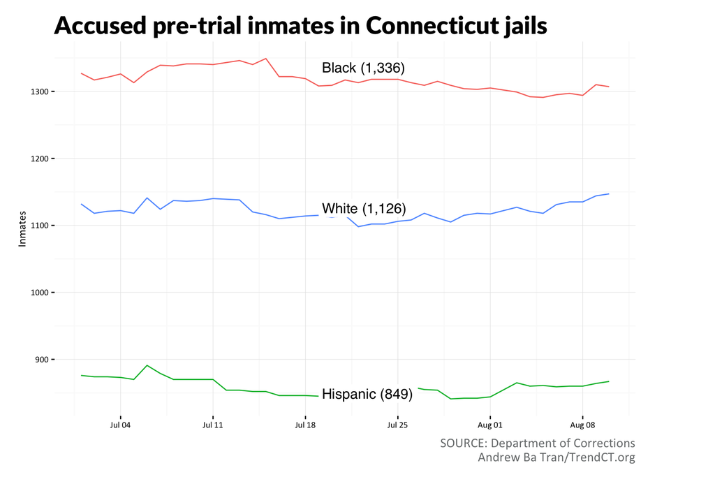

```r
# by date, race total
race_total_date <- update %>%
  group_by(DOWNLOAD.DATE, RACE) %>%
  summarise(total=n()) %>%
  filter(RACE=="BLACK" | RACE=="HISPANIC" | RACE=="WHITE")

race_total_date$DOWNLOAD.DATE <- mdy(race_total_date$DOWNLOAD.DATE)

gg <- ggplot(race_total_date, aes(x=DOWNLOAD.DATE, y=total, group=RACE, color=RACE)) + geom_line()
gg <- gg + labs(x=NULL, y="Inmates", title=paste("Accused pre-trial inmates in Connecticut jails"),
                caption="SOURCE: Department of Corrections\nAndrew Ba Tran/TrendCT.org")
gg <- gg + theme_bw(base_family="Calibri")
#gg <- gg + theme(panel.grid.major=element_blank())
#gg <- gg + theme(panel.grid.minor=element_blank())
gg <- gg + theme(panel.border=element_blank())
gg <- gg + theme(text = element_text(size=10))
#gg <- gg + theme(axis.ticks=element_blank())
#gg <- gg + theme(axis.text.x=element_blank())
gg <- gg + theme(plot.title=element_text(face="bold", family="Lato Black", size=22))
gg <- gg + theme(plot.subtitle=element_text(face="italic", size=9, margin=margin(b=12)))
gg <- gg + theme(plot.caption=element_text(size=12, margin=margin(t=10, r=80), color="#7a7d7e"))
gg <- gg + geom_label(data=race_total_date, aes(x=ymd("2016-7-19"), y=1336, label="Black (1,336)", hjust=0),
                      family="Helvetica", lineheight=0.95,
                      size=4.5, label.size=0, color="black")
gg <- gg + geom_label(data=race_total_date, aes(x=ymd("2016-7-19"), y=849, label="Hispanic (849)", hjust=0),
                      family="Helvetica", lineheight=0.95,
                      size=4.5, label.size=0, color="black")
gg <- gg + geom_label(data=race_total_date, aes(x=ymd("2016-7-19"), y=1126, label="White (1,126)", hjust=0),
                      family="Helvetica", lineheight=0.95,
                      size=4.5, label.size=0, color="black")
gg <- gg + theme(legend.position="none")
gg <- gg + theme(plot.margin = unit(c(1, 5, 1, 1), "lines"))
gg

gb <- ggplot_build(gg)
gt <- ggplot_gtable(gb)

gt$layout$clip[gt$layout$name=="panel"] <- "off"
grid.draw(gt)
```

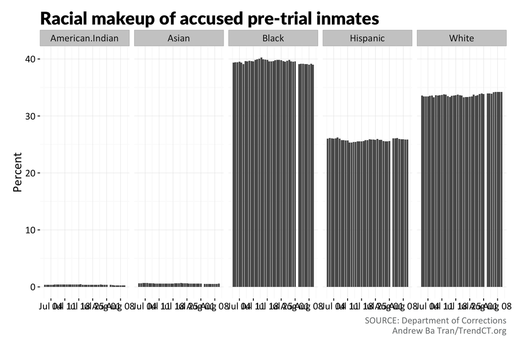

```r
ggsave(gt, file = "race_totals_time.png", width = 8, height = 6, type = "cairo-png")

race_total_date$RACE <- gsub(" ", ".", race_total_date$RACE)

race_total_date <- update %>%
  group_by(DOWNLOAD.DATE, RACE) %>%
  summarise(total=n()) %>%
  spread(RACE, total) %>%
  mutate(total = `AMER IND` + ASIAN + BLACK + HISPANIC + WHITE) %>%
  mutate(American.Indian.per = round(`AMER IND`/total*100,2), Asian.per = round(ASIAN/total*100,2), Black.per = round(BLACK/total*100,2), Hispanic.per = round(HISPANIC/total*100,2), White.per = round(WHITE/total*100,2)) %>%
  select(DOWNLOAD.DATE, American.Indian.per, Asian.per, Black.per, Hispanic.per, White.per) %>%
  gather(Race, Percent, 2:6)

race_total_date$Race <- gsub(".per", "", race_total_date$Race)

gg <- ggplot(race_total_date, aes(x=mdy(DOWNLOAD.DATE), y=Percent)) + geom_bar(stat="identity") + facet_grid(.~Race)
gg <- gg + labs(x=NULL, y="Percent", title=paste("Racial makeup of accused pre-trial inmates"),
                caption="SOURCE: Department of Corrections\nAndrew Ba Tran/TrendCT.org")
gg <- gg + theme_bw(base_family="Calibri")
gg <- gg + theme(text = element_text(size=16))
#gg <- gg + theme(panel.grid.major=element_blank())
#gg <- gg + theme(panel.grid.minor=element_blank())
gg <- gg + theme(panel.border=element_blank())
#gg <- gg + theme(axis.ticks=element_blank())
#gg <- gg + theme(axis.text.x=element_blank())
gg <- gg + theme(plot.title=element_text(face="bold", family="Lato Black", size=22))
gg <- gg + theme(plot.subtitle=element_text(face="italic", size=9, margin=margin(b=12)))
gg <- gg + theme(plot.caption=element_text(size=12, margin=margin(t=10, r=80), color="#7a7d7e"))
gg <- gg + theme(plot.margin = unit(c(1, 1, 1, 1), "lines"))

gg
```

```r
ggsave(gg, file = "race_percent_time.png", width = 8, height = 6, type = "cairo-png")
```

```r
female_total <- update %>%
  group_by(DOWNLOAD.DATE, GENDER) %>%
  summarise(total=n()) %>%
  spread(GENDER, total)

avg_females <- round(mean(female_total$F),0)
avg_males <- round(mean(female_total$M),0)

#round(avg_females/(avg_females+avg_males)*100)

median_females <- round(median(female_total$F),0)
median_males <- round(median(female_total$M),0)
```

### Men and women in jail awaiting trial

**Average number of women:** 343

**Average number of men:** 2989

**Median number of women:** 341

**Median number of men:** 2974

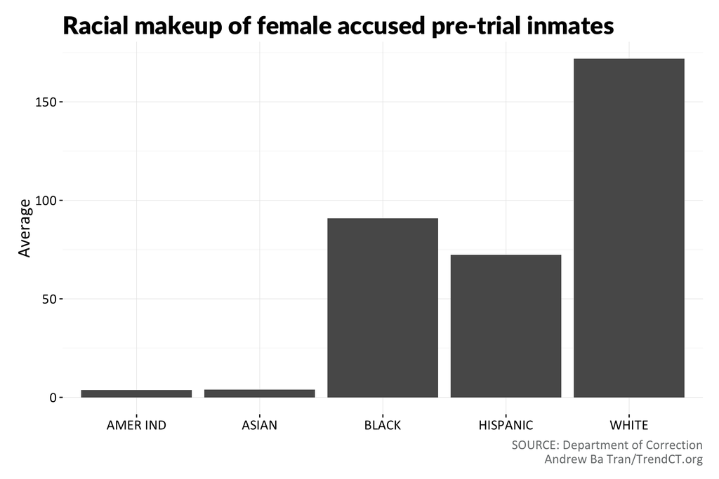

```r
female_total <- update %>%
  filter(GENDER=="F") %>%
  group_by(DOWNLOAD.DATE, RACE) %>%
  summarise(total=n()) %>%
  group_by(RACE) %>%
  summarise(avg=mean(total))

gg <- ggplot(female_total, aes(x=RACE, y=avg)) + geom_bar(stat="identity")
gg <- gg + labs(x=NULL, y="Average", title=paste("Racial makeup of female accused pre-trial inmates"),
                caption="SOURCE: Department of Correction\nAndrew Ba Tran/TrendCT.org")
gg <- gg + theme_bw(base_family="Calibri")
gg <- gg + theme(text = element_text(size=16))
#gg <- gg + theme(panel.grid.major=element_blank())
#gg <- gg + theme(panel.grid.minor=element_blank())
gg <- gg + theme(panel.border=element_blank())
#gg <- gg + theme(axis.ticks=element_blank())
#gg <- gg + theme(axis.text.x=element_blank())
gg <- gg + theme(plot.title=element_text(face="bold", family="Lato Black", size=22))
gg <- gg + theme(plot.subtitle=element_text(face="italic", size=9, margin=margin(b=12)))
gg <- gg + theme(plot.caption=element_text(size=12, margin=margin(t=10, r=80), color="#7a7d7e"))
gg <- gg + theme(plot.margin = unit(c(1, 1, 1, 1), "lines"))

gg
```

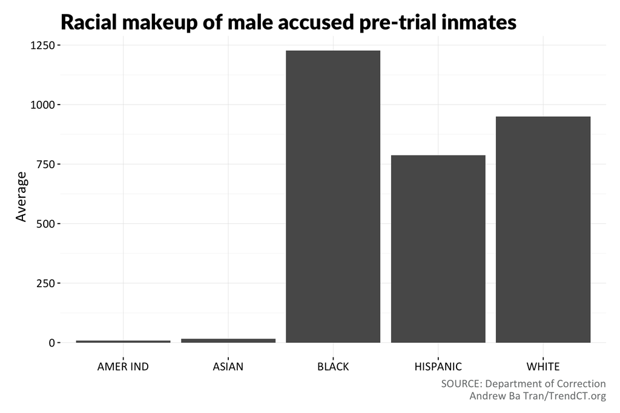

```r
male_total <- update %>%
  filter(GENDER=="M") %>%
  group_by(DOWNLOAD.DATE, RACE) %>%
  summarise(total=n()) %>%
  group_by(RACE) %>%
  summarise(avg=mean(total))

gg <- ggplot(male_total, aes(x=RACE, y=avg)) + geom_bar(stat="identity")
gg <- gg + labs(x=NULL, y="Average", title=paste("Racial makeup of male accused pre-trial inmates"),
                caption="SOURCE: Department of Correction\nAndrew Ba Tran/TrendCT.org")
gg <- gg + theme_bw(base_family="Calibri")
gg <- gg + theme(text = element_text(size=16))
#gg <- gg + theme(panel.grid.major=element_blank())
#gg <- gg + theme(panel.grid.minor=element_blank())
gg <- gg + theme(panel.border=element_blank())
#gg <- gg + theme(axis.ticks=element_blank())
#gg <- gg + theme(axis.text.x=element_blank())
gg <- gg + theme(plot.title=element_text(face="bold", family="Lato Black", size=22))
gg <- gg + theme(plot.subtitle=element_text(face="italic", size=9, margin=margin(b=12)))
gg <- gg + theme(plot.caption=element_text(size=12, margin=margin(t=10, r=80), color="#7a7d7e"))
gg <- gg + theme(plot.margin = unit(c(1, 1, 1, 1), "lines"))

gg
```

```r
avg_age <- update %>%
  group_by(RACE) %>%
  summarise(avg_age=round(mean(AGE),0), median_age=round(median(AGE),0))
```

### Average age by race

```r
kable(avg_age)
```

| RACE | avg_age | median_age |
| --- | --- | --- |
| AMER IND | 33 | 33 |
| ASIAN | 34 | 32 |
| BLACK | 32 | 29 |
| HISPANIC | 33 | 31 |
| WHITE | 36 | 33 |

```r
facilities <- update %>%
  group_by(DOWNLOAD.DATE, FACILITY) %>%
  summarise(total=n()) %>%
  group_by(FACILITY) %>%
  summarise(average=round(mean(total),0), median=round(median(total),0)) %>%
  arrange(-average)
```

### Average number of inmates by facility

```r
kable(facilities)
```

| FACILITY | average | median |
| --- | --- | --- |
| HARTFORD CC | 703 | 706 |
| BRIDGEPORT CC | 593 | 592 |
| NEW HAVEN CC | 539 | 540 |
| YORK CI | 341 | 340 |
| CORRIGAN CI | 324 | 325 |
| MANSON YI | 255 | 256 |
| NORTHERN CI | 174 | 174 |
| MACDOUGALL | 119 | 120 |
| GARNER | 111 | 108 |
| WALKER RC | 109 | 108 |
| OSBORN CI | 38 | 38 |
| CHESHIRE CI | 13 | 13 |
| MH-CVH | 3 | 3 |
| ROBINSON CI | 3 | 3 |
| FEDERAL MARSHAL | 2 | 2 |
| D KIMBALL HSP | 1 | 1 |
| ENFIELD CI | 1 | 1 |
| HARTFORD HOSP | 1 | 1 |
| LAWRENCE HOSP | 1 | 1 |
| MH-WHITING | 1 | 1 |
| ST MARYS HOSP | 1 | 1 |
| ST VINC HOSP | 1 | 1 |
| UCONN HOSP | 1 | 1 |
| WATERBRY HOSP | 1 | 1 |
| WILLARD-CYBULSKI CI | 1 | 1 |

```r
# Bond amount total by race

bonds <- update %>%
  group_by(RACE) %>%
  summarise(avg_bond=mean(BOND.AMOUNT), median_bond=median(BOND.AMOUNT))
```

### Bond amount by race

```r
kable(bonds)
```

| RACE | avg_bond | median_bond |
| --- | --- | --- |
| AMER IND | 74199.7 | 45000 |
| ASIAN | 145837.7 | 95000 |
| BLACK | 257451.2 | 100000 |
| HISPANIC | 205316.7 | 97650 |
| WHITE | 126895.2 | 50000 |

```r
update$offense_pre <- gsub(", .*", "", update$OFFENSE)
update$offense_degree <- gsub(".*, ", "", update$OFFENSE)

update$offense_degree <- ifelse(update$offense_pre==update$offense_degree, "", update$offense_degree)

fem_offense_list <- update %>%
  filter(GENDER=="F") %>%
  group_by(DOWNLOAD.DATE, offense_pre) %>%
  summarise(count=n()) %>%
  group_by(offense_pre) %>%
  summarise(avg=round(mean(count),0)) %>%
  arrange(-avg)
```

## Female offense list

```r
datatable(fem_offense_list)
```

|  | offense_pre | avg |
| --- | --- | --- |
| 1 | VIOLATION OF PROBATION OR COND DISCHG | 57 |
| 2 | FAILURE TO APPEAR | 39 |
| 3 | ASSAULT | 24 |
| 4 | LARCENY | 21 |
| 5 | BURGLARY | 19 |
| 6 | CRIM VIOL OF PROTECTIVE ORDER DF | 19 |
| 7 | INJURY OR RISK OF INJURY TO MINOR F | 18 |
| 8 | ROBBERY | 16 |
| 9 | ASSAULT ON POLICE OR FIRE OFFICER CF | 12 |
| 10 | CONSPIRACY | 8 |

[output cut: 61 more lines]

```r
mal_offense_list <- update %>%
  filter(GENDER=="M") %>%
  group_by(DOWNLOAD.DATE, offense_pre) %>%
  summarise(count=n()) %>%
  group_by(offense_pre) %>%
  summarise(avg=round(mean(count),0)) %>%
  arrange(-avg)
```

## Male offense list

```r
datatable(mal_offense_list)
```

|  | offense_pre | avg |
| --- | --- | --- |
| 1 | VIOLATION OF PROBATION OR COND DISCHG | 345 |
| 2 | ASSAULT | 262 |
| 3 | ROBBERY | 190 |
| 4 | BURGLARY | 158 |
| 5 | LARCENY | 155 |
| 6 | SEXUAL ASSAULT | 131 |
| 7 | CRIM VIOL OF PROTECTIVE ORDER DF | 120 |
| 8 | INJURY OR RISK OF INJURY TO MINOR F | 119 |
| 9 | SALE OF NARC/AMPHET BY NON-DEPENDENT F | 93 |
| 10 | MURDER AF | 88 |

[output cut: 159 more lines]

```r
mal_offense_race <- update %>%
  filter(GENDER=="M") %>%
  group_by(DOWNLOAD.DATE, offense_pre, RACE) %>%
  summarise(count=n()) %>%
  spread(RACE, count) %>%
  group_by(offense_pre) %>%
  summarise(amer.ind.avg=round(mean(`AMER IND`),0), asian.avg=round(mean(ASIAN),0), black.avg=round(mean(BLACK),0), hispanic.avg=round(mean(HISPANIC),0), white.avg=round(mean(WHITE),0)) %>%
  arrange(-white.avg)
```

## Male offense list by race

```r
datatable(mal_offense_race)
```

|  | offense_pre | amer.ind.avg | asian.avg | black.avg | hispanic.avg | white.avg |
| --- | --- | --- | --- | --- | --- | --- |
| 1 | VIOLATION OF PROBATION OR COND DISCHG |  |  | 112 | 86 | 147 |
| 2 | BURGLARY | 1 | 3 | 48 | 37 | 70 |
| 3 | ASSAULT |  | 2 | 121 | 73 | 65 |
| 4 | LARCENY | 1 | 2 | 52 | 36 | 64 |
| 5 | ROBBERY | 2 | 1 | 92 | 32 | 63 |
| 6 | CRIM VIOL OF PROTECTIVE ORDER DF |  | 2 | 41 | 28 | 49 |
| 7 | SEXUAL ASSAULT |  | 2 | 38 | 48 | 43 |
| 8 | FAILURE TO APPEAR |  |  | 24 | 22 | 34 |
| 9 | INJURY OR RISK OF INJURY TO MINOR F |  |  | 48 | 43 | 27 |
| 10 | POSSESSION OF NARCOTICS |  |  | 24 | 18 | 26 |

[output cut: 159 more lines]

```r
fem_offense_race <- update %>%
  filter(GENDER=="F") %>%
  group_by(DOWNLOAD.DATE, offense_pre, RACE) %>%
  summarise(count=n()) %>%
  spread(RACE, count) %>%
  group_by(offense_pre) %>%
  summarise(amer.ind.avg=round(mean(`AMER IND`),0), asian.avg=round(mean(ASIAN),0), black.avg=round(mean(BLACK),0), hispanic.avg=round(mean(HISPANIC),0), white.avg=round(mean(WHITE),0)) %>%
  arrange(-white.avg)
```

## Female offense list by race

```r
datatable(fem_offense_race)
```

|  | offense_pre | amer.ind.avg | asian.avg | black.avg | hispanic.avg | white.avg |
| --- | --- | --- | --- | --- | --- | --- |
| 1 | VIOLATION OF PROBATION OR COND DISCHG |  |  | 15 | 5 | 36 |
| 2 | FAILURE TO APPEAR |  |  | 6 | 4 | 29 |
| 3 | CRIM VIOL OF PROTECTIVE ORDER DF |  |  | 6 |  | 12 |
| 4 | ASSAULT |  |  | 7 | 7 | 9 |
| 5 | BURGLARY |  |  | 5 | 5 | 9 |
| 6 | LARCENY | 1 |  | 7 | 4 | 9 |
| 7 | INJURY OR RISK OF INJURY TO MINOR F |  | 1 | 4 | 5 | 8 |
| 8 | CONSPIRACY |  |  | 2 |  | 6 |
| 9 | ROBBERY |  |  | 7 | 4 | 5 |
| 10 | BREACH OF PEACE BM |  |  |  |  | 4 |

[output cut: 61 more lines]

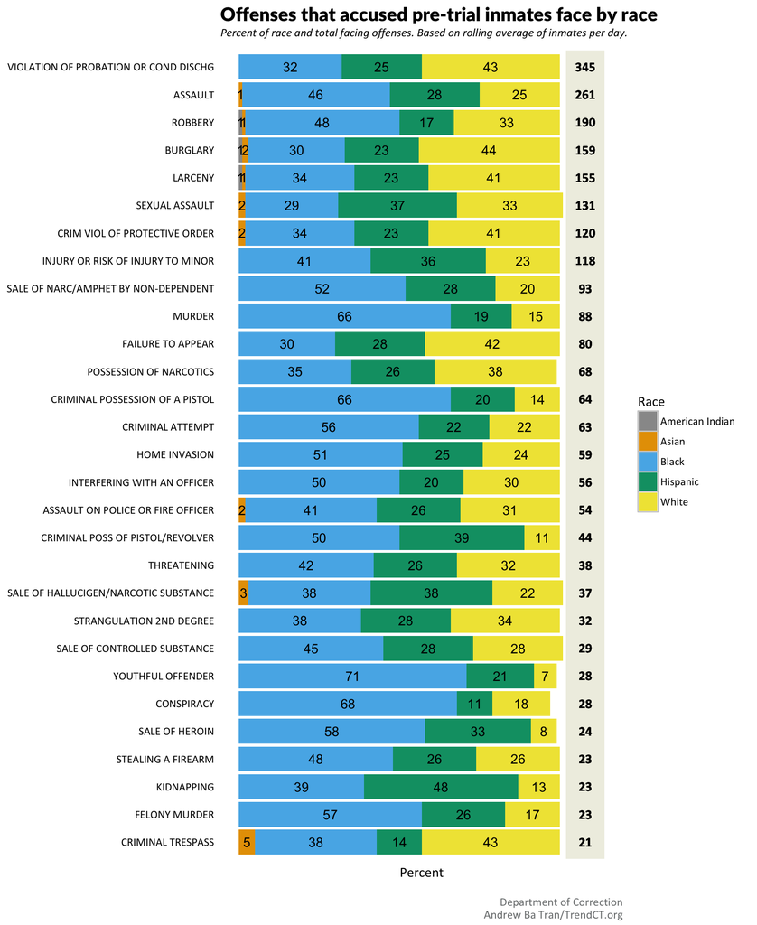

```r
mal_offense_race_percent <- update %>%
  filter(GENDER=="M") %>%
  group_by(DOWNLOAD.DATE, offense_pre, RACE) %>%
  summarise(count=n()) %>%
  spread(RACE, count) %>%
  group_by(offense_pre) %>%
  summarise(amer.ind.avg=round(mean(`AMER IND`),2), asian.avg=round(mean(ASIAN),0), black.avg=round(mean(BLACK),0), hispanic.avg=round(mean(HISPANIC),0), white.avg=round(mean(WHITE),0)) %>%
  arrange(-white.avg) %>%
  group_by(offense_pre) %>%
  mutate(total=sum(amer.ind.avg,asian.avg,black.avg,hispanic.avg,white.avg, na.rm=T)) %>%
  filter(total>20) %>%
  arrange(-total) %>%
  mutate(American.Indian.avg.per = round((amer.ind.avg/total)*100,0), Asian.avg.per = round(asian.avg/total*100,0),
Black.avg.per = round(black.avg/total*100,0), Hispanic.avg.per = round(hispanic.avg/total*100,0), White.avg.per = round(white.avg/total*100,0)) %>%
  select(offense_pre, total, American.Indian.avg.per, Asian.avg.per, Black.avg.per, Hispanic.avg.per, White.avg.per) %>%
  gather(Race, Percent, 3:7)

mal_offense_race_percent$Race <- gsub(".avg.per", "", mal_offense_race_percent$Race)
mal_offense_race_percent$Race <- gsub("\\.", " ", mal_offense_race_percent$Race)

#plotting it

library(plyr)
cbPalette <- c("#999999", "#E69F00", "#56B4E9", "#009E73", "#F0E442", "#0072B2", "#D55E00", "#CC79A7")

cbbPalette <- c("#000000", "#E69F00", "#56B4E9", "#009E73", "#F0E442", "#0072B2", "#D55E00", "#CC79A7")

Data <- mal_offense_race_percent
Data[is.na(Data)] <- 0
Data <- ddply(Data, .(offense_pre), transform, pos=cumsum(Percent)-(0.5*Percent))


Data$offense_pre <- gsub(" AM", "", Data$offense_pre)
Data$offense_pre <- gsub(" DF", "", Data$offense_pre)
Data$offense_pre <- gsub(" AF", "", Data$offense_pre)
Data$offense_pre <- gsub(" CF", "", Data$offense_pre)
Data$offense_pre <- gsub("  F", "", Data$offense_pre)
Data$offense_pre <- str_trim(Data$offense_pre)

Data[Data == 0] <- NA
Data <- Data[ order(-Data$total), ]

Data$offense_pre <- factor(Data$offense_pre, levels = Data$offense_pre[order(Data$total)])

gg <- ggplot(Data, aes(x = offense_pre, y = Percent))
gg <- gg + geom_bar(aes(fill = Race), stat="identity")
gg <- gg + geom_text(aes(label = Percent, y = pos), size = 4)
gg <- gg + scale_fill_manual(values=cbPalette)
gg <- gg + coord_flip()
gg <- gg + geom_rect(data=Data, aes(ymin=102, ymax=114, xmin=-Inf, xmax=Inf), fill="#efefe3")
gg <- gg + geom_text(data=Data, aes(label=round(total,0), x=offense_pre, y=108), fontface="bold", size=4, family="Calibri")
gg <- gg + labs(x=NULL, y="Percent", title="Offenses that accused pre-trial inmates face by race",
                subtitle="Percent of race and total facing offenses. Based on rolling average of inmates per day.",
                caption="Department of Correction\nAndrew Ba Tran/TrendCT.org")
gg <- gg + theme_bw(base_family="Calibri")
gg <- gg + theme(panel.grid.major=element_blank())
gg <- gg + theme(panel.grid.minor=element_blank())
gg <- gg + theme(panel.border=element_blank())
gg <- gg + theme(axis.ticks=element_blank())
gg <- gg + theme(axis.text.x=element_blank())
#gg <- gg + theme(text = element_text(size=20))
gg <- gg + theme(plot.title=element_text(face="bold", family="Lato Black", size=16))
gg <- gg + theme(plot.subtitle=element_text(face="italic", size=10,margin=margin(b=12)))
gg <- gg + theme(plot.caption=element_text(size=10, margin=margin(t=16), color="#7a7d7e"))
gg
```

```r
detach("package:plyr", unload=TRUE)

mal_offense_race_bond <- update %>%
  filter(GENDER=="M") %>%
  group_by(DOWNLOAD.DATE, OFFENSE, RACE) %>%
  summarise(total=n(),avg.bond=mean(BOND.AMOUNT)) %>%
  select(DOWNLOAD.DATE, OFFENSE, total, RACE, avg.bond) %>%
  spread(RACE, avg.bond) %>%
  group_by(OFFENSE) %>%
  summarise(total = sum(total), amer.ind.avg=round(mean(`AMER IND`, na.rm=T),2), asian.avg=round(mean(ASIAN, na.rm=T),0), black.avg=round(mean(BLACK, na.rm=T),0), hispanic.avg=round(mean(HISPANIC, na.rm=T),0), white.avg=round(mean(WHITE, na.rm=T),0)) %>%
  arrange(-white.avg) %>%
  filter(total>20)

mal_offense_race_bond$what <- ifelse(((mal_offense_race_bond$white.avg < mal_offense_race_bond$black.avg) & (mal_offense_race_bond$white.avg < mal_offense_race_bond$hispanic.avg)), "white", "minority")
```

## Bond amount

```r
datatable(mal_offense_race_bond)
```

|  | OFFENSE | total | amer.ind.avg | asian.avg | black.avg | hispanic.avg | white.avg | what |
| --- | --- | --- | --- | --- | --- | --- | --- | --- |
| 1 | CAPITAL FELONY F | 80 |  |  |  |  | 1332500 |  |
| 2 | MISCONDUCT WITH A MOTOR VEHICLE DF | 40 |  |  | 175500 |  | 1207000 | minority |
| 3 | FELONY MURDER AF | 908 |  |  | 1449497 | 860822 | 1127575 | minority |
| 4 | MURDER AF | 3534 |  |  | 1495355 | 1215514 | 1102756 | white |
| 5 | CRIMINAL LIABILITY FOR ANOTHER PERSON | 40 |  |  | 1501000 |  | 1025000 |  |
| 6 | PROHIBITED ACTIVITIES | 40 |  |  |  |  | 550000 |  |
| 7 | MANSLAUGHTER, FIRST DEGREE BF | 304 |  |  | 464165 | 260000 | 517900 | minority |
| 8 | MANSLAUGHTER 2ND WITH MV (INTOX) CF | 176 |  |  | 394562 | 208333 | 510000 | minority |
| 9 | EMPLOYING MINOR IN OBSCENE PERFORMNCE AF | 40 |  |  |  |  | 500000 |  |
| 10 | MANSLAUGHTER, FIRST DEGREE, FIREARM BF | 40 |  |  |  |  | 500000 |  |

[output cut: 167 more lines]

```r
days_list <- unique(update$DOWNLOAD.DATE)
update$auth.date <- mdy(update$DOWNLOAD.DATE)
update$first.date <- ifelse(mdy(update$LATEST.ADMISSION.DATE)>mdy("07/01/2016"), as.character(mdy(update$LATEST.ADMISSION.DATE)), as.character(mdy("07/01/2016")))
update$last.date <- ""

#3427

for (i in 2:length(days_list)) {
  date <- days_list[i-1]
  update_sub <- subset(update, DOWNLOAD.DATE==date)
  update_sub_solo <- update_sub[c("DOWNLOAD.DATE", "IDENTIFIER", "first.date")]

  date2 <- days_list[i]
  update_sub2 <- subset(update, DOWNLOAD.DATE==date2)
  update_sub_solo2 <- update_sub2[c("DOWNLOAD.DATE", "IDENTIFIER", "first.date")]
  update_sub_combined <- full_join(update_sub_solo, update_sub_solo2, by="IDENTIFIER")

  update_sub_combined$first.date <- ifelse(is.na(update_sub_combined$DOWNLOAD.DATE.x), as.character(mdy(as.character(update_sub_combined$DOWNLOAD.DATE.y))), as.character(ymd(update_sub_combined$first.date.x)))
  update_sub_combined$last.date <- ifelse(is.na(update_sub_combined$DOWNLOAD.DATE.y), as.character(mdy(as.character(update_sub_combined$DOWNLOAD.DATE.x))), "")

  update_sub_combined <- update_sub_combined[c("IDENTIFIER","first.date","last.date")]

  if (i == 2) {
    update_all <- update_sub_combined
  } else {
    update_all <- rbind(update_all, update_sub_combined)
  }
  update_all_complete <- update_all[!duplicated(update_all), ]

}

dupes <- update_all_complete[duplicated(update_all_complete$IDENTIFIER),]
dupes$dupe <- "duplicate"
dupes <- dupes[c("IDENTIFIER", "dupe")]

update_all_complete <- left_join(update_all_complete, dupes)
duped <- subset(update_all_complete, dupe=="duplicate")
duped <- arrange(duped, IDENTIFIER)

for (i in 1:nrow(duped)) {
  if ((duped$IDENTIFIER[i]== duped$IDENTIFIER[i+1]) & (i !=nrow(duped))) {

    if (duped$first.date[i] == duped$first.date[i+1]) {
      duped$last.date[i] <- ifelse(duped$last.date[i]=="", duped$last.date[i+1], duped$last.date[i])
      duped$last.date[i+1] <- ifelse(duped$last.date[i]=="", duped$last.date[i+1], duped$last.date[i])

    }

    if (duped$first.date[i] > duped$first.date[i+1]) {
      duped$first.date[i] <- duped$first.date[i+1]
    }

    if (duped$first.date[i] < duped$first.date[i+1]) {
      duped$first.date[i + 1] <- duped$first.date[i]
    }

  }

}

duped <- unique(duped)

update_all_complete_final <- subset(update_all_complete, is.na(dupe))
update_all_complete_final <- rbind(update_all_complete_final, duped)

update$auth.date <- NULL
update$first.date <- NULL
update$last.date <- NULL

update <- left_join(update, update_all_complete_final, by="IDENTIFIER")
update$dupe <- NULL
update$first.date[update$first.date == "2016-07-01"] <- NA
update$total.days <- ymd(update$last.date) - ymd(update$first.date)

write.csv(table(update$total.days, update$RACE), "race_days.csv")
```

## Median days spent in jail (of those who came and left between July 1 and today

```r
median_d <- update %>%
  group_by(RACE) %>%
  summarise(Days=median(total.days, na.rm=T))

kable(median_d)
```

| RACE | Days |
| --- | --- |
| AMER IND | 29 days |
| ASIAN | 7 days |
| BLACK | 16 days |
| HISPANIC | 15 days |
| WHITE | 14 days |

```r
avg_d <- update %>%
  group_by(RACE) %>%
  summarise(Days=mean(total.days, na.rm=T))
kable(median_d)
```

| RACE | Days |
| --- | --- |
| AMER IND | 29 days |
| ASIAN | 7 days |
| BLACK | 16 days |
| HISPANIC | 15 days |
| WHITE | 14 days |

```r
out <- subset(update, !is.na(total.days))
still_in <- subset(update, is.na(total.days))
out_yet <- subset(still_in, last.date=="")
still_in <- subset(still_in, last.date!="")


out2 <- count(out[unique(out$IDENTIFIER),])
out_yet2 <- count(out_yet[unique(out_yet$IDENTIFIER),])
still_in2 <- count(still_in[unique(still_in$IDENTIFIER),])
```

## Inmate turnover

Pre-trial inmates who arrived after July 1 and has since left jail * 626

```r
total_inmates <- length(unique(update$IDENTIFIER))


still_in_t <- still_in[unique(still_in$IDENTIFIER),] %>%
  group_by(RACE) %>%
  summarise(count=n())

kable(still_in_t)
```

| RACE | count |
| --- | --- |
| AMER IND | 13 |
| ASIAN | 6 |
| BLACK | 432 |
| HISPANIC | 346 |
| WHITE | 469 |

## Inmates still who came in to jail and have left

```r
out_t <- out[unique(out$IDENTIFIER),] %>%
  group_by(RACE) %>%
  summarise(count=n())

kable(out_t)
```

| RACE | count |
| --- | --- |
| AMER IND | 5 |
| ASIAN | 3 |
| BLACK | 194 |
| HISPANIC | 136 |
| WHITE | 243 |
| NA | 45 |

```r
out_yet_t <- out_yet[unique(out_yet$IDENTIFIER),] %>%
  group_by(RACE) %>%
  summarise(count=n())

kable(out_yet_t)
```

| RACE | count |
| --- | --- |
| AMER IND | 9 |
| ASIAN | 33 |
| BLACK | 1708 |
| HISPANIC | 1022 |
| WHITE | 1246 |